# **APRENDIZAJE AUTOMATICO Y CIENCIA DE DATOS**

### READMISION

La variable “readmitted” indica si los pacientes fueron readmitidos tras su alta.

Proporciones de las variables en Readmitted

| Variable | Proporción |
| --- | --- |
| readmitted | 0.4608944 |

Una proporción del 46.09% de los pacientes regresó al hospital, lo que sugiere que casi la mitad de los casos podrían necesitar una evaluación adicional para identificar factores que influyen en las readmisiones, como la efectividad del tratamiento o el manejo post-alta.

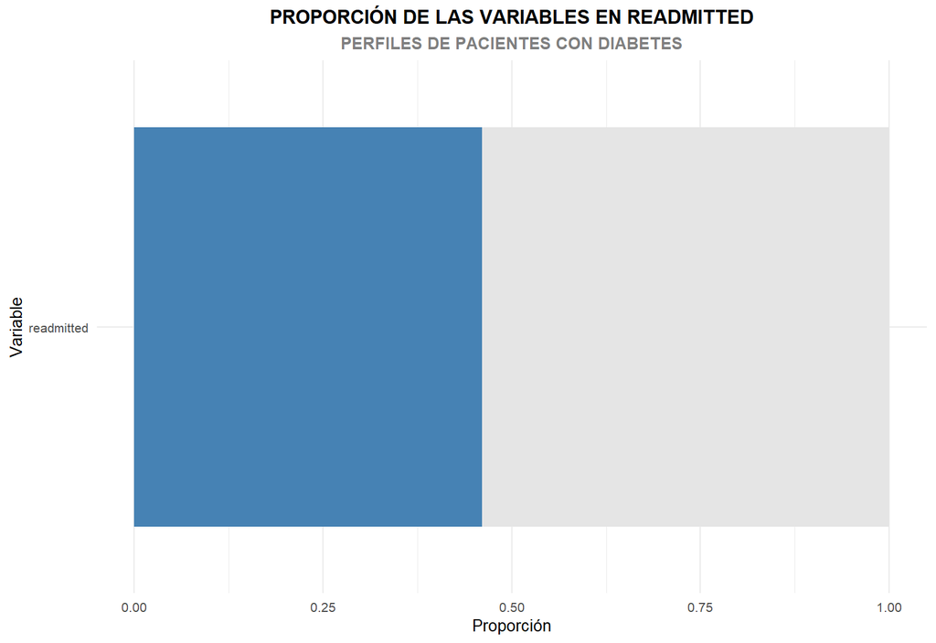

```r
T_Prop_readmitted %>%
  mutate(Sobrante = 1 - Proporcion) %>%
  ggplot(aes(x = reorder(Variable, Proporcion))) +
  geom_bar(aes(y = 1), stat = "identity", fill = "grey90") +  # Barra gris del 100%
  geom_bar(aes(y = Proporcion), stat = "identity", fill = "steelblue") +  # Barra azul de la proporción
  coord_flip() +
  ggtitle(label = "PROPORCIÓN DE LAS VARIABLES EN READMITTED",
          subtitle = "PERFILES DE PACIENTES CON DIABETES") +
  labs(x = "Variable", y = "Proporción") +
  theme_minimal() +
  theme(plot.title = element_text(size = 12, face = "bold", hjust = 0.5),
        legend.position = "none", text = element_text(size = 10),
        plot.subtitle = element_text(size = 10, face = "bold", hjust = 0.5, color = "grey50"))
```

En general, las variables analizadas revelan un panorama de tratamiento y control de la diabetes en una población de pacientes. La mayoría de los tratamientos y medicaciones (como metformina, repaglinida, acarbosa, entre otros) no son utilizados por la mayoría de los pacientes, con una proporción significativa recibiendo tratamientos estables o constantes. Los ajustes en las dosis de estos medicamentos son mínimos, lo que sugiere que muchos pacientes tienen un tratamiento controlado y sin cambios frecuentes en su dosificación.

En resumen, aunque muchos pacientes tienen un tratamiento estable y bien administrado, el control de la glucosa en sangre en algunos casos no es óptimo, lo que podría implicar la necesidad de intervenciones adicionales para mejorar el manejo de la diabetes y sus complicaciones asociadas.

## **VARIABLES NUMERICAS**

### TIEMPO EN EL HOSPITAL

La variable “Time in Hospital” representa la duración de las estancias hospitalarias en días. Los valores van desde un mínimo de 1 día hasta un máximo de 14 días.

Resumen de la variable Time in Hospital

| Variable | Valor |
| --- | --- |
| Min. | 1.000000 |
| 1st Qu. | 2.000000 |
| Median | 4.000000 |
| Mean | 4.396018 |
| 3rd Qu. | 6.000000 |
| Max. | 14.000000 |

La mediana es de 4 días, lo que indica que la mitad de las estancias son de 4 días o menos. El promedio es ligeramente mayor (4.40 días), lo que sugiere la presencia de algunas estancias más largas que elevan este valor. La mayoría de las estancias se concentran entre 2 días (primer cuartil) y 6 días (tercer cuartil).

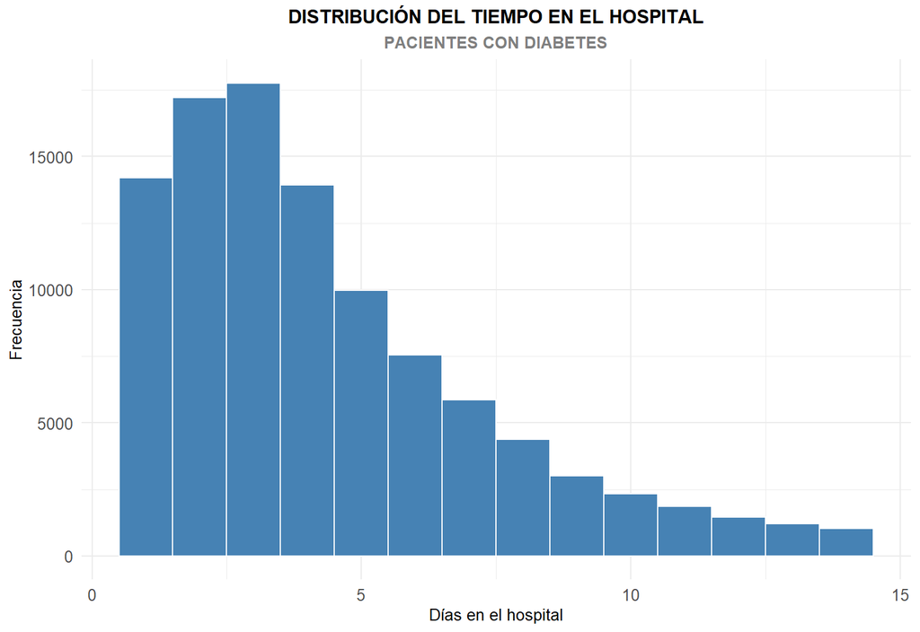

```r
data %>%
  ggplot(aes(x = time_in_hospital)) +
  geom_histogram(binwidth = 1, fill = "steelblue", color = "white") +
  ggtitle(label = "DISTRIBUCIÓN DEL TIEMPO EN EL HOSPITAL",
          subtitle = "PACIENTES CON DIABETES") +
  labs(x = "Días en el hospital", y = "Frecuencia") +
  theme_minimal() +
  theme(plot.title = element_text(size = 12, face = "bold", hjust = 0.5),
        plot.subtitle = element_text(size = 10, face = "bold", hjust = 0.5, color = "grey50"),
        axis.text = element_text(size = 10),
        axis.title = element_text(size = 10))
```

### NUMERO DE PROCEDIMIENTOS DE LABORATORIO

La variable “Num Lab Procedures” representa el número de procedimientos de laboratorio realizados durante la estancia hospitalaria.

Resumen de la variable Num Lab Procedures

| Variable | Valor |
| --- | --- |
| Min. | 1.00000 |
| 1st Qu. | 31.00000 |
| Median | 44.00000 |
| Mean | 43.09591 |
| 3rd Qu. | 57.00000 |
| Max. | 132.00000 |

Los valores oscilan entre un mínimo de 1 y un máximo de 132 procedimientos. La mediana es de 44, lo que indica que la mitad de los pacientes tiene 44 o menos procedimientos. El promedio es de 43.10, cercano a la mediana, lo que sugiere una distribución relativamente equilibrada. La mayoría de los valores se encuentran entre 31 (primer cuartil) y 57 (tercer cuartil), reflejando que estos son los rangos típicos de procedimientos realizados.

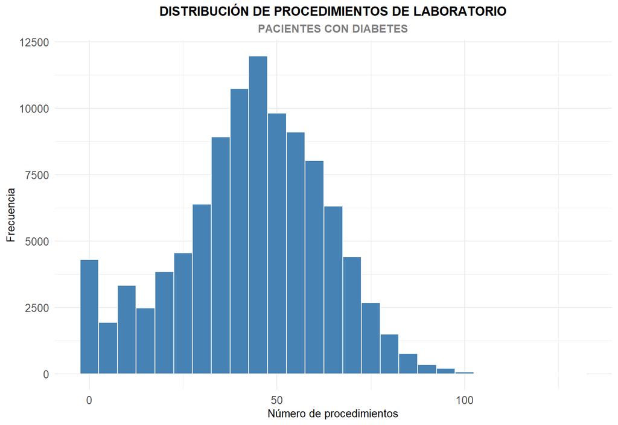

```r
# Grafica

data %>%
  ggplot(aes(x = num_lab_procedures)) +
  geom_histogram(binwidth = 5, fill = "steelblue", color = "white") +
  ggtitle(label = "DISTRIBUCIÓN DE PROCEDIMIENTOS DE LABORATORIO",
          subtitle = "PACIENTES CON DIABETES") +
  labs(x = "Número de procedimientos", y = "Frecuencia") +
  theme_minimal() +
  theme(plot.title = element_text(size = 12, face = "bold", hjust = 0.5),
        plot.subtitle = element_text(size = 10, face = "bold", hjust = 0.5, color = "grey50"),
        axis.text = element_text(size = 10),
        axis.title = element_text(size = 10))
```

### NUMERO DE PROCEDIMIENTOS

La variable “Num Procedures” representa el número de procedimientos realizados durante la estancia hospitalaria.

Resumen de la variable Num Procedures

| Variable | Valor |
| --- | --- |
| Min. | 0.000000 |
| 1st Qu. | 0.000000 |
| Median | 1.000000 |
| Mean | 1.339691 |
| 3rd Qu. | 2.000000 |
| Max. | 6.000000 |

El valor mínimo es 0, lo que indica que algunos pacientes no recibieron procedimientos. La mediana es 1, lo que significa que la mitad de los pacientes tuvieron 1 o menos procedimientos. El promedio es de 1.34, lo que sugiere que, en general, los pacientes se someten a pocos procedimientos. La mayoría de los pacientes tuvieron entre 0 y 2 procedimientos, con un valor máximo de 6 procedimientos. Esto refleja que la mayoría de los casos fueron relativamente simples en términos de intervenciones.

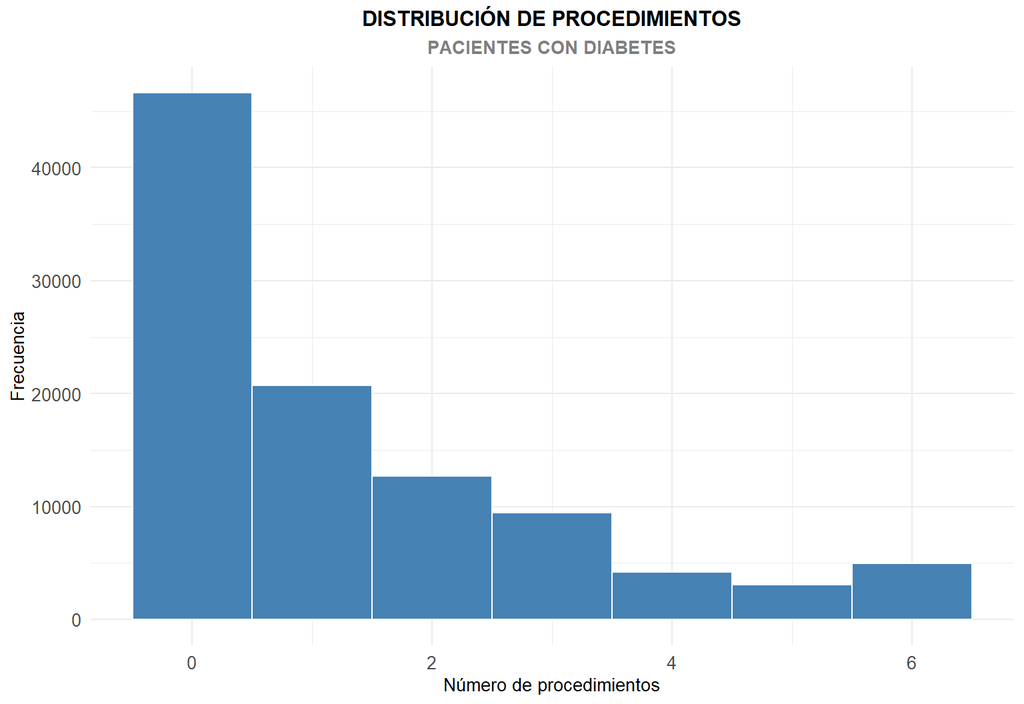

```r
data %>%
  ggplot(aes(x = num_procedures)) +
  geom_histogram(binwidth = 1, fill = "steelblue", color = "white") +
  ggtitle(label = "DISTRIBUCIÓN DE PROCEDIMIENTOS",
          subtitle = "PACIENTES CON DIABETES") +
  labs(x = "Número de procedimientos", y = "Frecuencia") +
  theme_minimal() +
  theme(plot.title = element_text(size = 12, face = "bold", hjust = 0.5),
        plot.subtitle = element_text(size = 10, face = "bold", hjust = 0.5, color = "grey50"),
        axis.text = element_text(size = 10),
        axis.title = element_text(size = 10))
```

### NUMERO DE MEDICAMENTOS

La variable “Num Medications” refleja el número de medicamentos administrados durante la estancia hospitalaria.

Resumen de la variable Num Medications

| Variable | Valor |
| --- | --- |
| Min. | 1.00000 |
| 1st Qu. | 10.00000 |
| Median | 15.00000 |
| Mean | 16.02183 |
| 3rd Qu. | 20.00000 |
| Max. | 81.00000 |

Los valores varían entre un mínimo de 1 medicamento y un máximo de 81. La mediana es 15, lo que indica que la mitad de los pacientes recibió 15 o menos medicamentos. El promedio es de 16.02, lo que sugiere que, en general, los pacientes reciben un número relativamente alto de medicamentos durante su atención. La mayoría de los pacientes se encuentra entre 10 y 20 medicamentos (primer y tercer cuartil), lo que refleja un rango común de tratamiento en la muestra.

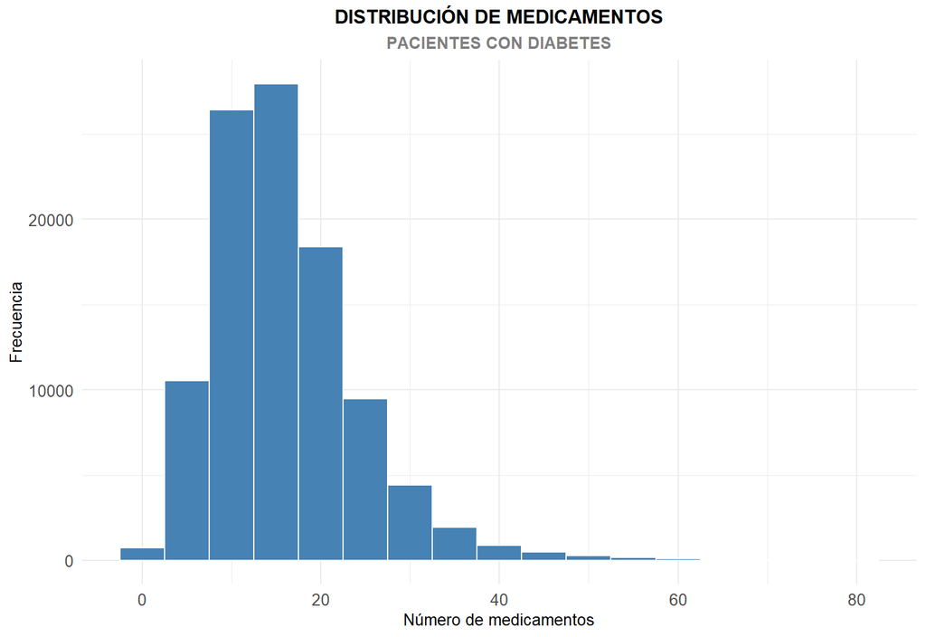

```r
data %>%
  ggplot(aes(x = num_medications)) +
  geom_histogram(binwidth = 5, fill = "steelblue", color = "white") +
  ggtitle(label = "DISTRIBUCIÓN DE MEDICAMENTOS",
          subtitle = "PACIENTES CON DIABETES") +
  labs(x = "Número de medicamentos", y = "Frecuencia") +
  theme_minimal() +
  theme(plot.title = element_text(size = 12, face = "bold", hjust = 0.5),
        plot.subtitle = element_text(size = 10, face = "bold", hjust = 0.5, color = "grey50"),
        axis.text = element_text(size = 10),
        axis.title = element_text(size = 10))
```

### NUMERO DE OUTPATIENT

La variable “Number Outpatient” refleja el número de visitas ambulatorias previas al ingreso hospitalario.

Resumen de la variable Number Outpatient

| Variable | Valor |
| --- | --- |
| Min. | 0.000000 |
| 1st Qu. | 0.000000 |
| Median | 0.000000 |
| Mean | 0.369368 |
| 3rd Qu. | 0.000000 |
| Max. | 42.000000 |

La mayoría de los pacientes no tiene visitas ambulatorias registradas (mínimo, primer cuartil y mediana son 0). Sin embargo, el valor promedio es de 0.37 visitas, lo que indica que, en promedio, algunos pacientes tienen una o más visitas ambulatorias antes de su hospitalización, aunque la mayoría no tiene ninguna. El valor máximo es 42 visitas, lo que sugiere que existen algunos pacientes con un historial ambulatorio más extenso antes de ser ingresados.

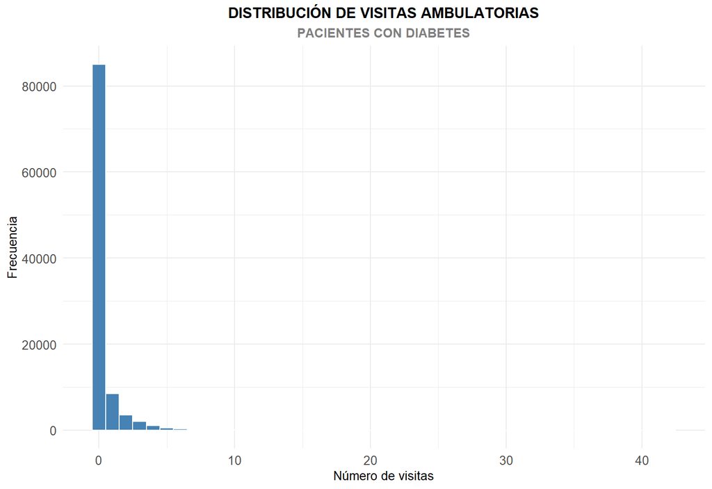

```r
# Grafica

data %>%
  ggplot(aes(x = number_outpatient)) +
  geom_histogram(binwidth = 1, fill = "steelblue", color = "white") +
  ggtitle(label = "DISTRIBUCIÓN DE VISITAS AMBULATORIAS",
          subtitle = "PACIENTES CON DIABETES") +
  labs(x = "Número de visitas", y = "Frecuencia") +
  theme_minimal() +
  theme(plot.title = element_text(size = 12, face = "bold", hjust = 0.5),
        plot.subtitle = element_text(size = 10, face = "bold", hjust = 0.5, color = "grey50"),
        axis.text = element_text(size = 10),
        axis.title = element_text(size = 10))
```

### NUMERO DE EMERGENCY

La variable “Number Emergency” refleja el número de visitas de emergencia previas al ingreso hospitalario.

Resumen de la variable Number Emergency

| Variable | Valor |
| --- | --- |
| Min. | 0.000000 |
| 1st Qu. | 0.000000 |
| Median | 0.000000 |
| Mean | 0.197842 |
| 3rd Qu. | 0.000000 |
| Max. | 76.000000 |

La mayoría de los pacientes no tiene visitas de emergencia registradas (mínimo, primer cuartil y mediana son 0). El promedio es de 0.20 visitas, lo que indica que, en general, los pacientes tienen pocas visitas a emergencias antes de su hospitalización. Sin embargo, el valor máximo es 76, lo que sugiere que algunos pacientes pueden haber tenido un número considerable de visitas a emergencias antes de ser admitidos en el hospital.

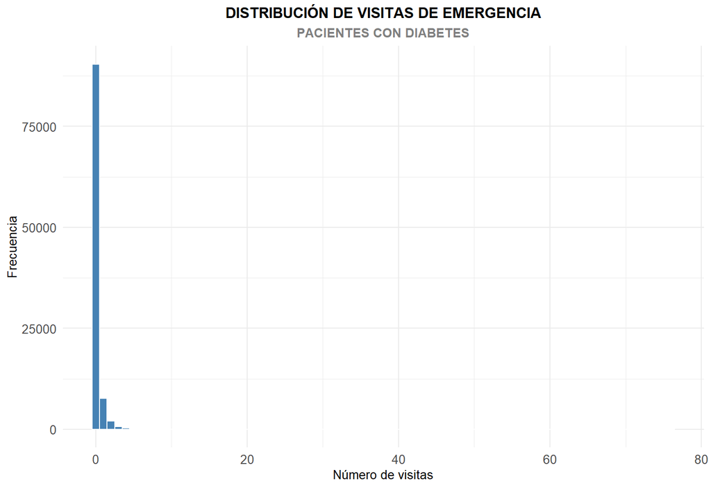

```r
# Grafica

data %>%
  ggplot(aes(x = number_emergency)) +
  geom_histogram(binwidth = 1, fill = "steelblue", color = "white") +
  ggtitle(label = "DISTRIBUCIÓN DE VISITAS DE EMERGENCIA",
          subtitle = "PACIENTES CON DIABETES") +
  labs(x = "Número de visitas", y = "Frecuencia") +
  theme_minimal() +
  theme(plot.title = element_text(size = 12, face = "bold", hjust = 0.5),
        plot.subtitle = element_text(size = 10, face = "bold", hjust = 0.5, color = "grey50"),
        axis.text = element_text(size = 10),
        axis.title = element_text(size = 10))
```

### NUMERO DE INPATIENTE

La variable “Number Inpatient” refleja el número de ingresos hospitalarios previos al ingreso actual.

Resumen de la variable Number Inpatient

| Variable | Valor |
| --- | --- |
| Min. | 0.0000000 |
| 1st Qu. | 0.0000000 |
| Median | 0.0000000 |
| Mean | 0.6355846 |
| 3rd Qu. | 1.0000000 |
| Max. | 21.0000000 |

La mayoría de los pacientes no tiene ingresos previos registrados (mínimo, primer cuartil y mediana son 0). El promedio es de 0.64 ingresos, lo que indica que, en general, los pacientes tienen pocos ingresos previos. El tercer cuartil es 1, lo que significa que la mayoría de los pacientes ha tenido 0 o 1 ingreso anterior. El valor máximo es 21, lo que sugiere que algunos pacientes tienen un historial significativo de hospitalizaciones previas.

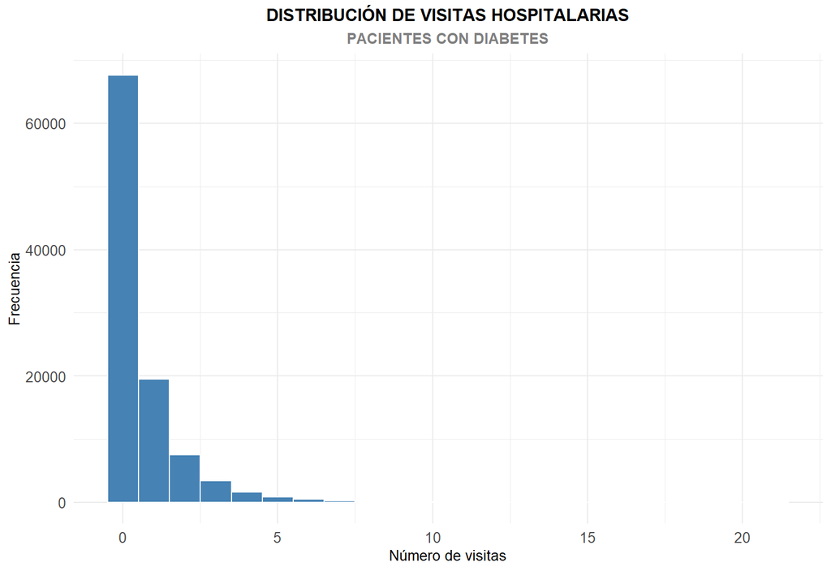

```r
# Grafica

data %>%
  ggplot(aes(x = number_inpatient)) +
  geom_histogram(binwidth = 1, fill = "steelblue", color = "white") +
  ggtitle(label = "DISTRIBUCIÓN DE VISITAS HOSPITALARIAS",
          subtitle = "PACIENTES CON DIABETES") +
  labs(x = "Número de visitas", y = "Frecuencia") +
  theme_minimal() +
  theme(plot.title = element_text(size = 12, face = "bold", hjust = 0.5),
        plot.subtitle = element_text(size = 10, face = "bold", hjust = 0.5, color = "grey50"),
        axis.text = element_text(size = 10),
        axis.title = element_text(size = 10))
```

### NUMERO DE DIAGNOSTICOS

La variable “Number Diagnoses” representa el número de diagnósticos registrados durante la estancia hospitalaria.

Resumen de la variable Number Diagnoses

| Variable | Valor |
| --- | --- |
| Min. | 1.000000 |
| 1st Qu. | 6.000000 |
| Median | 8.000000 |
| Mean | 7.422649 |
| 3rd Qu. | 9.000000 |
| Max. | 16.000000 |

El valor mínimo es 1, lo que indica que todos los pacientes tienen al menos un diagnóstico. La mediana es 8, lo que sugiere que la mitad de los pacientes tiene 8 o menos diagnósticos. El promedio es de 7.42, lo que refleja que en general los pacientes tienen múltiples diagnósticos, pero no de manera excesiva. La mayoría de los pacientes tiene entre 6 y 9 diagnósticos (primer y tercer cuartil), y el valor máximo es 16, lo que indica que algunos pacientes pueden ser diagnosticados con múltiples condiciones complejas.

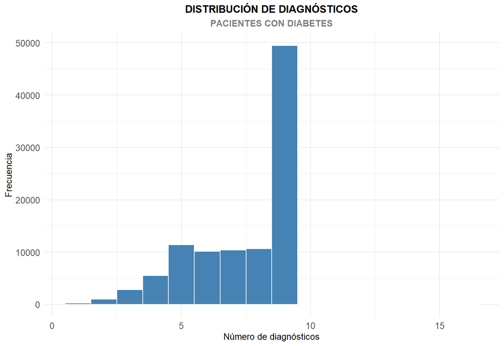

```r
# Grafica

data %>%
  ggplot(aes(x = number_diagnoses)) +
  geom_histogram(binwidth = 1, fill = "steelblue", color = "white") +
  ggtitle(label = "DISTRIBUCIÓN DE DIAGNÓSTICOS",
          subtitle = "PACIENTES CON DIABETES") +
  labs(x = "Número de diagnósticos", y = "Frecuencia") +
  theme_minimal() +
  theme(plot.title = element_text(size = 12, face = "bold", hjust = 0.5),
        plot.subtitle = element_text(size = 10, face = "bold", hjust = 0.5, color = "grey50"),
        axis.text = element_text(size = 10),
        axis.title = element_text(size = 10))
```

## **MATRIZ DE CORRELACIÓN**

A continuacion se presenta la matriz de correlación de las variables numéricas.

Matriz de Correlación de Variables Numéricas

|  | time_in_hospital | num_lab_procedures | num_procedures | num_medications | number_outpatient | number_emergency | number_inpatient | number_diagnoses |
| --- | --- | --- | --- | --- | --- | --- | --- | --- |
| time_in_hospital | 1.0000000 | 0.3184294 | 0.1914972 | 0.4661374 | -0.0089192 | -0.0096834 | 0.0736190 | 0.2201530 |
| num_lab_procedures | 0.3184294 | 1.0000000 | 0.0581055 | 0.2681757 | -0.0076064 | -0.0022824 | 0.0392252 | 0.1527374 |
| num_procedures | 0.1914972 | 0.0581055 | 1.0000000 | 0.3857607 | -0.0248127 | -0.0381753 | -0.0662263 | 0.0737692 |
| num_medications | 0.4661374 | 0.2681757 | 0.3857607 | 1.0000000 | 0.0451983 | 0.0131803 | 0.0641960 | 0.2615288 |
| number_outpatient | -0.0089192 | -0.0076064 | -0.0248127 | 0.0451983 | 1.0000000 | 0.0914570 | 0.1073340 | 0.0941483 |
| number_emergency | -0.0096834 | -0.0022824 | -0.0381753 | 0.0131803 | 0.0914570 | 1.0000000 | 0.2665574 | 0.0555355 |
| number_inpatient | 0.0736190 | 0.0392252 | -0.0662263 | 0.0641960 | 0.1073340 | 0.2665574 | 1.0000000 | 0.1047026 |
| number_diagnoses | 0.2201530 | 0.1527374 | 0.0737692 | 0.2615288 | 0.0941483 | 0.0555355 | 0.1047026 | 1.0000000 |

En cuanto a la medicación, los pacientes reciben en promedio 16 medicamentos, lo que refleja tratamientos médicos complejos. La mayoría de los pacientes no tiene visitas ambulatorias ni de emergencia previas al ingreso, aunque algunos sí tienen antecedentes de múltiples visitas a emergencias. Además, aunque la mayoría de los pacientes no tiene hospitalizaciones previas, algunos tienen un historial de múltiples ingresos, lo que puede sugerir condiciones más crónicas. Finalmente, los pacientes tienen entre 6 y 9 diagnósticos, lo que muestra que su atención médica generalmente abarca varias condiciones diferentes.

Por ultimo, la siguiente figura, corresponde al mapa de calor de las variables numéricas, donde se puede observar la relación entre las variables de una forma más clara y dinamica.

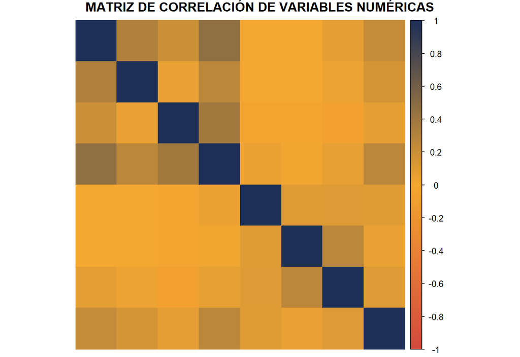

```r
# Crear el mapa de calor con la función corrplot
corrplot(correlation_matrix,
         tl.pos = "n",  # No mostrar etiquetas de texto
         tl.col = "black",  # Color de las etiquetas
         cl.cex = 0.8,  # Ajustar el tamaño de la leyenda
         order = "original",  # Ordenar las variables según un dendrograma jerárquico
         method = "color",  # Usar colores en el mapa de calor
         col = colorRampPalette(c('#D14B3D','#F5A831','#1D2F57'))(200),  # Definir la paleta de colores
         title = "MATRIZ DE CORRELACIÓN DE VARIABLES NUMÉRICAS",  # Título
         mar = c(0,0,1,0)  # Ajustar márgenes
)
```

Aquí se puede observar que no hay correlaciones fuertes entre las variables numéricas, lo que sugiere que no hay una relación lineal clara entre ellas. Esto indica que las variables numéricas representan aspectos diferentes de la atención médica y el tratamiento de los pacientes, lo que refleja la complejidad y diversidad de las condiciones de salud y los tratamientos asociados.

## **BASE FINAL**

Luego de las transformaciones y análisis realizados, la base de datos final se presenta a continuación.

```
## Rows: 101,763
## Columns: 36
## $ time_in_hospital    <dbl> 4, 2, 4, 5, 1, 7, 6, 3, 2, 3, 2, 4, 3, 3, 1, 4, 5,…
## $ num_lab_procedures  <dbl> 66, 48, 21, 38, 6, 42, 43, 26, 24, 60, 10, 32, 63,…
## $ num_procedures      <dbl> 3, 0, 3, 0, 0, 2, 2, 1, 3, 0, 0, 2, 4, 2, 4, 0, 6,…
## $ num_medications     <dbl> 18, 15, 23, 5, 6, 27, 17, 16, 17, 19, 3, 35, 17, 2…
## $ number_outpatient   <dbl> 0, 4, 1, 0, 0, 0, 0, 0, 0, 0, 0, 0, 0, 1, 0, 0, 0,…
## $ number_emergency    <dbl> 0, 0, 0, 0, 0, 0, 0, 0, 0, 0, 0, 0, 0, 0, 0, 0, 0,…
## $ number_inpatient    <dbl> 1, 0, 2, 0, 0, 0, 0, 1, 0, 0, 0, 0, 0, 2, 0, 1, 0,…
## $ number_diagnoses    <dbl> 9, 7, 7, 2, 6, 2, 5, 8, 9, 9, 9, 9, 4, 9, 4, 9, 9,…
## $ change              <dbl> 1, 0, 0, 1, 0, 1, 0, 0, 0, 1, 0, 0, 0, 0, 1, 1, 1,…
## $ diabetesMed         <dbl> 1, 0, 1, 1, 1, 1, 1, 1, 1, 1, 0, 0, 1, 0, 1, 1, 1,…
## $ readmitted          <dbl> 1, 0, 0, 0, 1, 0, 0, 1, 0, 0, 0, 0, 1, 1, 0, 0, 1,…
## $ Raza                <chr> "Caucásico", "Caucásico", "Caucásico", "Caucásico"…
## $ Genero              <chr> "Femenino", "Femenino", "Femenino", "Femenino", "M…
```

[output cut: 23 more lines]

Podemos ver como pasamos de tener 151 variables a tener solo 36, al unificar las categoricas en una sola, con esto tambien podemos observar, que tenos un total de 8 variables de tipo numerico y 28 de tipo categorico.

Trabajado por: Cesar Prieto - CapStatsML

*https://github.com/CapStats-ML*